# Research Worldwide Bureaucracy Indicators to help implement efficient public policies

Proposal

Project proposal description

Author

Affiliation

Mohammad Rahat Helal

School of Information, University of Arizona

## Setup

```r
if (!require ("pacman"))
  install.packages("pacman")

# use this line for installing/loading
pacman::p_load(here,
               tidyverse,
               ggrepel,
               devtools,
               tidytuesdayR,
               dplyr,
               readr,
               janitor,
               ggplot2)

# Set a CRAN mirror
options(repos = c(CRAN = "https://cloud.r-project.org"))
```

## Dataset

I have selected the datasets from the Worldwide Bureaucracy Indicators (WWBI) for my final project and referred to “Worldwide Bureaucracy Indicators” (2024a) for more information. Three underlying datasets (merged on bureaucratic indicators and countries) cover the overall aspect of understanding jobs and salary information for almost all countries world wide. The three datasets in the respective csv files are named as “wwbi_data”, “wwbi_series”, and “wwbi_country”. These datasets could be further explained below:

- **wwbi_data** consists of information on the country code, bureaucracy indicator code, year and numeric value of data.
- **wwbi_series** contains the bureaucracy indicator code and the name of the indicator
- **wwbi_country** dataset comprises of country code, detailed information on country’s name, currency, region, income group etc. The other factual data on surveys conducted and latest data on core economy attributes such as agriculture, industries, trade, and population census are a part of this dataset.

I have downloaded the data from the required github source and performed initial cleaning steps to get a well-defined data version for research questions and visualization. I took a few initial analytics steps, such as joining two datasets to gather information on specific indicators to help understand and develop project-related questions.

The steps to download the required datasets and load them in data/2024/2024-04-30 location can be found below:

```r
# download the three files containing WWBI data
invisible(capture.output(tuesdata <- tidytuesdayR::tt_load('2024-04-30')))

# Create separate dataframes for each part - data, series, and country
wwbi_data <- tuesdata$wwbi_data
wwbi_series <- tuesdata$wwbi_series
wwbi_country <- tuesdata$wwbi_country

# glimpse(wwbi_country)
# glimpse(wwbi_series)
# glimpse(wwbi_data)
```

Below is the data cleansing steps outlined in the source git repository “Worldwide Bureaucracy Indicators” (2024b)

```r
# Clean the data downloaded from the WWBI website and
# load the three csv files into data folder

working_dir <- here::here("data", "2024", "2024-04-30")

url <- "https://databank.worldbank.org/data/download/WWBI_CSV.zip"

# file_path <- withr::local_tempfile(fileext = ".zip")
# download.file(url, file_path, quiet = TRUE)
#
# extract_dir <- withr::local_tempdir("csvs")
# unzip(file_path, exdir = extract_dir)

suppressMessages({
  file_path <- withr::local_tempfile(fileext = ".zip")
  download.file(url, file_path, quiet = TRUE)
  extract_dir <- withr::local_tempdir("csvs")
  unzip(file_path, exdir = extract_dir)
})

wwbi_country <- readr::read_csv(
  fs::path(extract_dir, "WWBICountry.csv")
) |>
  janitor::clean_names() |>
  janitor::remove_empty("cols") |>
  dplyr::mutate(
    # Several columns are years, make them integers
    national_accounts_reference_year = as.integer(national_accounts_reference_year),
    latest_industrial_data = as.integer(latest_industrial_data),
    latest_trade_data = as.integer(latest_trade_data),
    latest_population_census_year = as.integer(stringr::str_extract(
      latest_population_census,
      "^\\d{4}"
    )),
    latest_agricultural_census = as.integer(stringr::str_extract(
      latest_agricultural_census,
      "^\\d{4}"
    )),
    national_accounts_base_year = as.integer(stringr::str_extract(
      national_accounts_base_year,
      "^\\d{4}"
    )),
    system_of_national_accounts = as.integer(stringr::str_extract(
      system_of_national_accounts,
      "\\d{4}"
    )),
    latest_population_census_notes = stringr::str_remove(
      latest_population_census,
      "^\\d{4}\\.?\\s*"
    ),
    latest_population_census_notes = dplyr::na_if(
      latest_population_census_notes,
      ""
    ),
    # vital_registration_complete is either "yes" or "NA"
    vital_registration_complete = !is.na(vital_registration_complete)
  ) |>
  dplyr::select(-"latest_population_census")

wwbi_series <- readr::read_csv(
  fs::path(extract_dir, "WWBISeries.csv"),
  col_types = paste(rep("c", 21), collapse = "")
) |>
  janitor::clean_names() |>
  janitor::remove_empty("cols") |>
  dplyr::rename(indicator_code = "series_code")

wwbi_data <- readr::read_csv(
  fs::path(extract_dir, "WWBIData.csv"),
  col_types = paste(c(rep("c", 4), rep("d", 21), "c"), collapse = "")
) |>
  janitor::clean_names() |>
  # indicator_name and country_name are redundant.
  dplyr::select(-"indicator_name", -"country_name") |>
  janitor::remove_empty("cols") |>
  tidyr::pivot_longer(
    cols = -c(country_code, indicator_code),
    names_to = "year",
    names_transform = ~ as.integer(stringr::str_remove(.x, "x")),
    values_to = "value"
  ) |>
  dplyr::filter(!is.na(value))

readr::write_csv(
  wwbi_data,
  fs::path(working_dir, "wwbi_data.csv")
)
readr::write_csv(
  wwbi_series,
  fs::path(working_dir, "wwbi_series.csv")
)
readr::write_csv(
  wwbi_country,
  fs::path(working_dir, "wwbi_country.csv")
)
```

### Reason for selecting this dataset

I am interested in understanding and researching data that could help gain insights into current scenarios of public policies and their actual on-ground implementation, understand the trends across geographies, and take lessons on how to improve or suggest improvements in country-specific needs and situations. I believe the analytics and visualizations created as part of the final project will help me understand and convey to a larger audience the correct and expected implementations of public policies. I gather from my initial analysis that some variables and indicators provide various public policy information that could help bureaucrats and government policymakers study and improve the current situation in their respective countries.

## Questions

The two questions I want to answer:

Research the variables and investigate if they can be applied or accepted uniformly across countries or if they will portray different pictures, i.e., convey dissimilar messages based on the underlying survey data. For example, the latest agricultural census data varies for every country. Not all have performed the census recently, so merging the analysis and concluding something specific for each would be difficult. Similarly, the four blog posts mentioned on the webpage only cover topics on jobs and gender participation but miss the point on other indicators valuable in understanding the importance of other indicator priorities. Hence, out of the vast amount of information present in the combined datasets, I want to narrow down to two critical aspects and so my questions would be:

### Question 1:

Compare the different regions globally, research how has public sector employment changed over time? Pick up one country in a region and research if there are underlying factors for such changes?

### Question 2:

In context of public administration in different geographies, what is the relationship between income group and public administration efficiency?

## Analysis plan

- A plan for answering each of the questions including the variables involved, variables to be created (if any), external data to be merged in (if any).

Join the data across the three datasets to build an understanding of underlying data based on the indicators of interest such as public jobs, gender participation in the workforce, and the role of recent agriculture, industrial, and trade surveys in further understanding if all the policies are aligned as expected.

For question 1, I have merged the three datasets into a single dataset on indicator code and country code and then filtered it to check records for public sector employment. This data subset allows me to review the distribution in one region and then compare all the regions over the many years. The two plots have been shown one after the other. The data analysis will be continued to look for patterns in a particular country in a region and narrow down to specific factors affecting public sector employment.

The columns that will be used for answering this question:

- indicator_name: it is a char data type and the field represents indicator names such as “Public Sector Employment” for this question.
- indicator_code: this is also a char data type and it depicts the codes for various bureaucracy indicators such as “BI.EMP.TOTL.PB.ZS” used for answering question 1.
- year: it is an integer data type and consists of years for all records.
- region: it is a char data type and has all geographies contained in it.

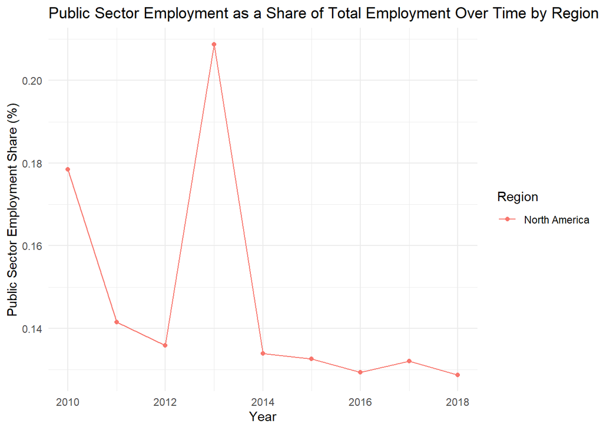

```r
# replicate base data into three dataframes to analyze question 1
country_df <- wwbi_country
data_df <- wwbi_data
series_df <- wwbi_series

# merge the three data frames on indicator code and country code
merged_df <- merge(data_df, series_df, by = "indicator_code")
merged_df <- merge(merged_df, country_df, by = "country_code")

# Public sector employment
ps_empl_indicator <- merged_df %>%
  filter(str_detect(str_to_lower(indicator_name), "public sector employment"))

distinct_ps_empl_ind <- ps_empl_indicator %>%
  distinct(indicator_code, indicator_name)

# print(distinct_ps_empl_ind)

grouped_ps_empl_ind <- ps_empl_indicator %>%
  group_by(indicator_code, indicator_name) %>%
  summarise(record_count = n(), .groups = "drop") %>%
  arrange(desc(record_count))

# print(grouped_ps_empl_ind)

# Filter for the public sector employment indicator
employment_data <- merged_df %>%
  filter(indicator_code == "BI.EMP.TOTL.PB.ZS")

# print(employment_data)

# Aggregate data by year and region
# aggregated_data <- employment_data %>%
#   group_by(year, region) %>%
#   summarise(mean_value = mean(value, na.rm = TRUE))

# Aggregate data by year and region
aggregated_data <- employment_data %>%
  group_by(year, region) %>%
  summarise(mean_value = mean(value, na.rm = TRUE), .groups = "drop")

aggregated_data_na <- aggregated_data %>%
  filter(region == "North America")

ggplot(aggregated_data_na, aes(x = year, y = mean_value, color = region)) +
  geom_line() +
  geom_point() +
  labs(title = "Public Sector Employment as a Share of Total Employment Over Time by Region",
       x = "Year",
       y = "Public Sector Employment Share (%)",
       color = "Region") +
  theme_minimal()
```

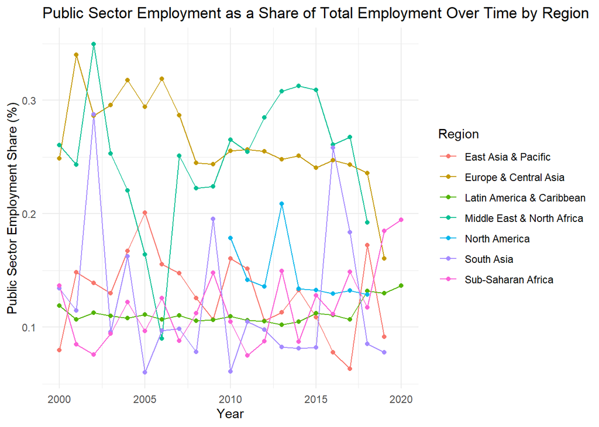

```r
# Plot the data
ggplot(aggregated_data, aes(x = year, y = mean_value, color = region)) +
  geom_line() +
  geom_point() +
  labs(title = "Public Sector Employment as a Share of Total Employment Over Time by Region",
       x = "Year",
       y = "Public Sector Employment Share (%)",
       color = "Region") +
  theme_minimal()
```

For question 2, I have filtered out the indicators that pertain to either government, administration or efficiency and then merged that subset of data with the other datasets. The plot then shows the distribution of different income groups and public administration efficiency over years. However, I could see that few indicators do not fit the criteria of research here and needs to be removed/modified. For example, the indicators similar to “Number of employed employees, by industry: Public Administration” may or may not be of use when analyzing the overall efficiency of administration. There will be a change of strategy for these kind of scenarios.

The fields selected for the analysis of this question and plotting a suitable graph are as follow:

- indicator_name: it is a char data type and the field represents indicator names such as those similar to “Administration” for this question.
- indicator_code: this is also a char data type and it depicts the codes for various bureaucracy indicators, similar to previous question.
- country_code: this is a char data type and has a three letter code for each country.
- income_group: a char data type field that shows grouping of income for different population sizes.
- year: it is an integer data type and consists of years for all records.

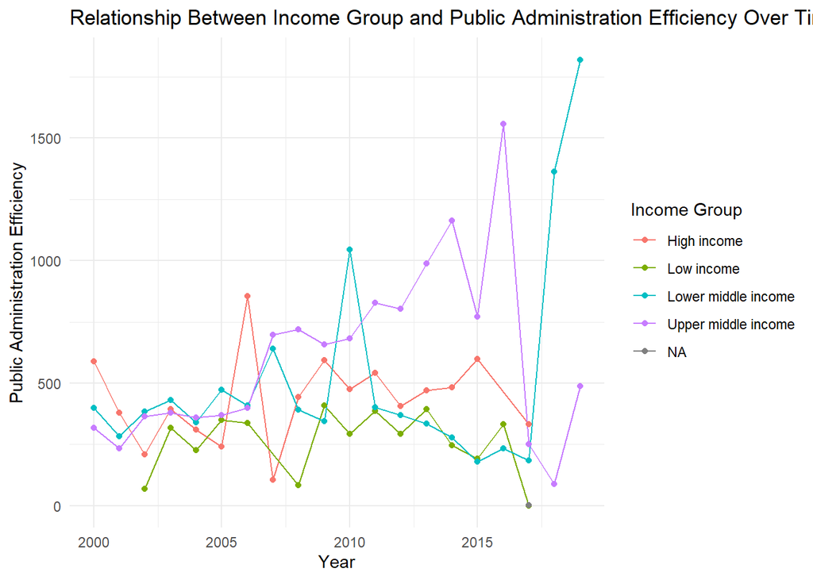

```r
# Read the data

country_df_2 <- wwbi_country
data_df_2 <- wwbi_data
series_df_2 <- wwbi_series

# country_df_2 <- country_df_2 %>%
#   clean_names() %>%
#   remove_empty("cols")

# efficiency_indicators <- series_df_2 %>%
#   filter(str_detect(str_to_lower(indicator_name), "public administration efficiency"))

# Check available indicators related to public administration or efficiency
relevant_indicators <- series_df_2 %>%
  filter(str_detect(str_to_lower(indicator_name), "administration|government|efficiency"))

# View relevant indicators
# print(relevant_indicators)

# Filter data_df for these indicators
efficiency_data <- data_df_2 %>%
  filter(indicator_code %in% relevant_indicators$indicator_code)

# Merge data_df with country_df to get income group information
merged_df_2 <- merge(efficiency_data, country_df_2, by = "country_code")

# Aggregate and visualize the data
efficiency_aggregated_2 <- merged_df_2 %>%
  group_by(income_group, year) %>%
  summarise(mean_efficiency = mean(value, na.rm = TRUE), .groups = "drop")

# Plot the data
ggplot(efficiency_aggregated_2, aes(x = year, y = mean_efficiency, color = income_group)) +
  geom_line() +
  geom_point() +
  labs(title = "Relationship Between Income Group and Public Administration Efficiency Over Time",
       x = "Year",
       y = "Public Administration Efficiency",
       color = "Income Group") +
  theme_minimal()
```

- Schedule:
  - Week starting June 3: Review feedback on the proposal and close any remaining issues. Work on the presentation in presentation.qmd and write-up in index.qmd.
  - Week starting June 10: Work on project
    - Week starting June 17: Finalize your write-up, presentation, and your project website. Record presentation for class by Monday (June 24th)

      Workflow

      | Task Name | Status | Assignee | Due | Priority | Summary |
      | --- | --- | --- | --- | --- | --- |
      | Preliminary data analysis | Completed | Mohammad Rahat Helal | June 10 | High | The underlying data from the three wwbi datasets have been analyzed, fields selected for both questions to be answered |
      | Analyze data and generate plots | Completed | Mohammad Rahat Helal | June 17 | High | Come up with suitable plots for the two questions |
      | Finalize plots and ppt | Completed | Mohammad Rahat Helal | June 24 | High | Complete the plots for two questions and work on presentation |
      | Final Submission | Completed | Mohammad Rahat Helal | June 26 | High | Publish and render website to sync all files for online access |

## References

“Worldwide Bureaucracy Indicators.” 2024a. 2024. https://datacatalog.worldbank.org/search/dataset/0038132.

———. 2024b. 2024. https://github.com/rfordatascience/tidytuesday/blob/master/data/2024/2024-04-30/readme.md.